# Simulating Roulette

Xiaohe (Marina) Yue

9/18/2019

# Introduction for the roulette game

A roulette table composed of 38 (or 37) evenly sized pockets on a wheel. The pockets are colored red, black, or green. The pockets are also numbered. Roulette is a game of chance in which a pocket is randomly selected. Gamblers may wager on several aspects of the outcome. For example, one may place a wager that the randomly selected pocket will be red or odd numbered or will be a specific number.

For this time analysis, all one needs to know is that there are 38 pockets of which 2 are green, 18 are red, and 18 are black. The payout for a bet on black (or red) is $1 for each $1 wagered. This means that if a gambler bets $1 on black and the randomly selected pocket is black, then the gambler will get the original $1 wager and an additional $1 as winnings.

# A single play of the Martingale strategy

This classic type of strategy is based on the idea that you will double your bet after losing trades and, in theory, you will always cover your losses with winning bets that are double the amount of the losing bet.

Consider how the strategy playes out for a single sequence of spins {Black, Black, Red}.

| Play | Wager | Outcome | Earnings |
| --- | --- | --- | --- |
| 1 | 1 | Black | -1 |
| 2 | 2 | Black | -3 |
| 3 | 4 | Red | +1 |

The Martingale strategy appears to always end in positive earnings, regardless of how unlucky a string of spins may be. Is the strategy actually profitable?

# Setting goals

How we used computer simulation to understand the operating characteristics of the above strategy.

# Simulation and analysis

### Simulating the strategy with multiple iterations

In order to determine whether Martingale strategy is a safe or not, we need to repeat the simulation enough times to mimic the reality. By using this simulation, we can find the probability of earning money with the Martingale strategy.

```r
#' Takes a state list, spins the roulette wheel, returns the state list with updated values (for example, budget, plays, etc)
#' @param state A list with the following entries:
#'   B              number, the budget
#'   W              number, the budget threshold for successfully stoping
#'   L              number, the maximum number of plays
#'   M              number, the casino wager limit
#'   plays          integer, the number of plays executed
#'   previous_wager number, the wager in the previous play (0 at first play)
#'   previous_win   TRUE/FALSE, indicator if the previous play was a win (TRUE at first play)
#' @return The updated state list

library(dplyr)
```

```r
library(ggplot2)
one_play <- function(state){
    # browser()
    # Wager
    proposed_wager <- ifelse(state$previous_win, 1, 2*state$previous_wager)
    wager <- min(proposed_wager, state$M, state$B)

    # Spin of the wheel
    red <- rbinom(1,1,18/38)

    # Update state
    state$plays <- state$plays + 1
    state$previous_wager <- wager
    if(red){
      # WIN
      state$B <- state$B + wager
      state$previous_win <- TRUE
    }else{
      # LOSE
      state$B <- state$B - wager
      state$previous_win <- FALSE
    }
  state
}

#' Stopping rule
#'
#' Takes the state list and determines if the gambler has to stop
#' @param state A list.  See one_play
#' @return TRUE/FALSE
stop_play <- function(state){
  # browser()
  if(state$B <= 0) return(TRUE)
  if(state$plays >= state$L) return(TRUE)
  if(state$B >= state$W) return(TRUE)
  FALSE
}


#' Play roulette to either bankruptcy, success, or play limits
#'
#' @param B number, the starting budget
#' @param W number, the budget threshold for successfully stoping
#' @param L number, the maximum number of plays
#' @param M number, the casino wager limit
#' @return A vector of budget values calculated after each play.

one_series <- function(
    B = 200
  , W = 300
  , L = 1000
  , M = 100
){

  # initial state
  state <- list(
    B = B
  , W = W
  , L = L
  , M = M
  , plays = 0
  , previous_wager = 0
  , previous_win = TRUE
  )
  # browser()
  # vector to store budget over series of plays
  budget <- rep(NA, L)

  # For loop of plays
  for(i in 1:L){
    new_state <- state %>% one_play
    budget[i] <- new_state$B
    # browser()
    if(new_state %>% stop_play){
      return(budget[1:i])
    }
    state <- new_state
  }
  budget
}

# helper function
get_last <- function(x) x[length(x)]

# Simulation
walk_out_money <- rep(NA, 2000)
for(j in seq_along(walk_out_money)){
  walk_out_money[j] <- one_series(B = 200, W = 300, L = 1000, M = 100) %>% get_last
}
```

First, let us assume that we have 200 dollars in our pocket, and we want to know the frequency of earning certain amounts of money if we play roulette tonight. We follow the strategy that talked about before and assume that we will quit the game after we have 300 dollars in total as our budget or we lose all the money. Moreover, since we are not planning to play the game all night, we will set the play limit as 1000.

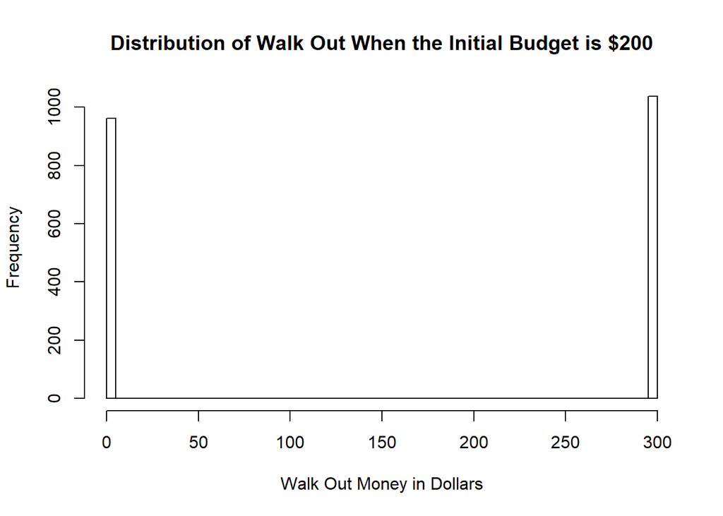

```r
# Walk out money distribution
hist(walk_out_money, breaks = 100, xlab = "Walk Out Money in Dollars", ylab = "Frequency", main = "Distribution of Walk Out When the Initial Budget is $200")
```

As you can see, the result is about 50/50 for people who walk out with 0 cent and people who walk out with $300 including $200 initial budget.

Now, let us calculate the average winning rate. What is our chance of leaving the casino with extra money by using this strategy? According to our simulation, just about half of the players is expected to quit the game with extra money.

```
## [1] 0.519
```

Then what about the earnings? What is the average earning in the simulation? By calculation, we figure out that the average earning is actually negative here, which means that the Martingale strategy actually results in an average loss.

```
## [1] -44.3365
```

Now, we can provide a figure that show how the gamblers earnings (or losses) evolve over a series of wagers at the roulette wheel. Here, the x-axis will be the wager number (or play number), the y-axis will be earnings. We could see that in one specific series, before the gambler stops, the difference between loss or gain is small. From the distribution of earnings graph, it is interesting to see that when the play number is at certain time (around 70 here), the earnings drops extremely.

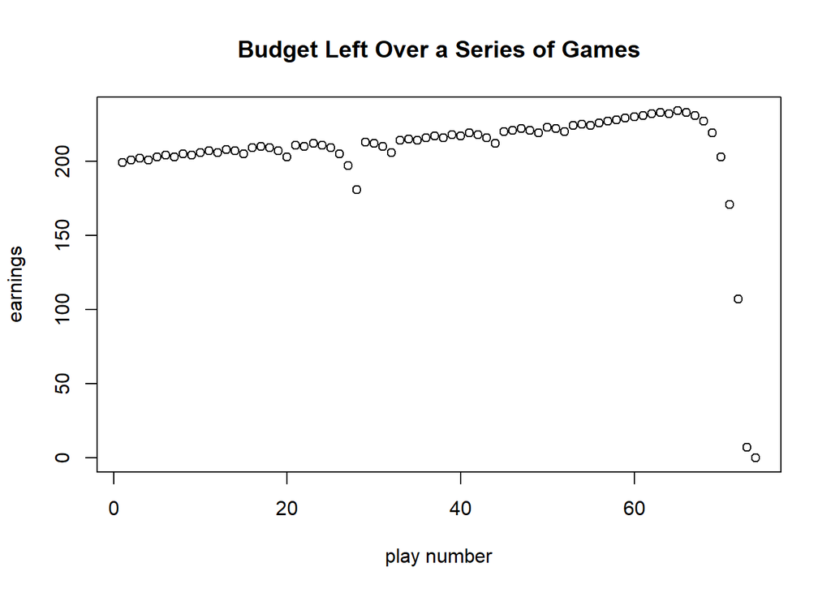

```r
set.seed(2)
plot(one_series(), main=paste("Budget Left Over a Series of Games"), xlab="play number", ylab="earnings")
```

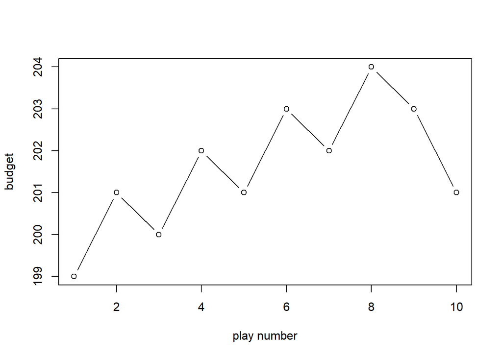

```r
plot(one_series()[1:10], type = "b",  xlab="play number", ylab="budget")
```

### Adjusting the condition

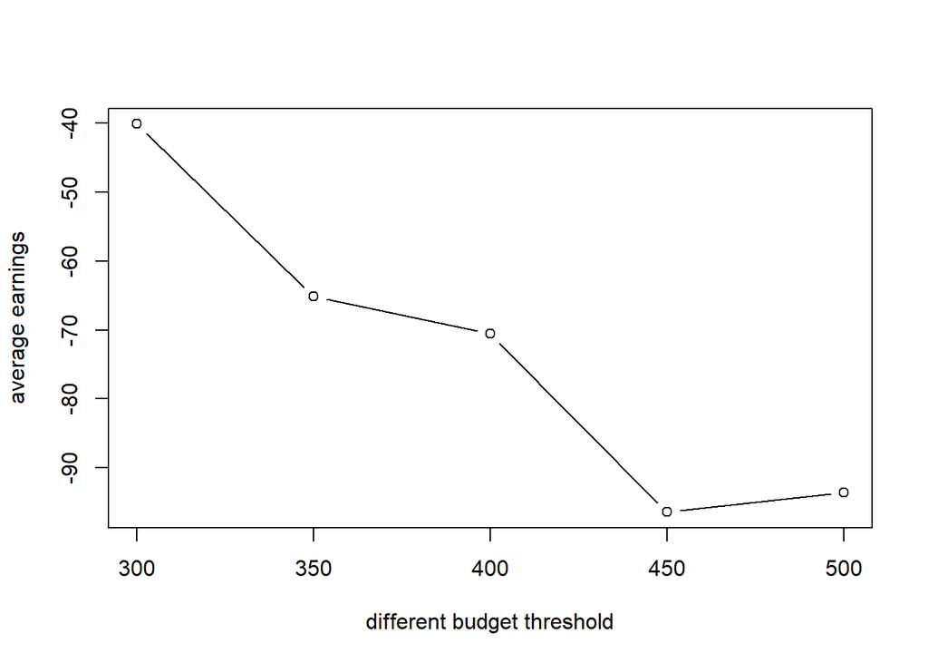

```r
walk_out_money <- rep(NA, 1000)
change_W <- function(W){
  for(j in seq_along(walk_out_money)){
  walk_out_money[j] <- one_series(B = 200, W, L = 1000, M = 100) %>% get_last
}
set<-c()
count <- 0
while(count<1000) {

    add <- walk_out_money-200
    set <- c(set,add)
    count=count+1
}
return(set)
}

list<-c(mean(change_W(300)),mean(change_W(350)),mean(change_W(400)),mean(change_W(450)),mean(change_W(500)))
xw <- seq(300,500,50)
plot(x= xw, y = list,xlab="different budget threshold", ylab="average earnings",type = "b")
```

### Estimating the average number of plays before stopping

```r
set_play<-c()
i <- 0
while(i < 1000) {

    add_play <- length(one_series())
    set_play <- c(set_play,add_play)
    i=i+1
}
mean(set_play)
```

```
## [1] 200.436
```

# Limitation or source of uncertainty

- We are not sure if a gambler have enough time to stay in this casino and win his money back.
- We are not sure if a gambler’s heart is strong enough from losing money first; we are not sure if he is patient enough for winning money back later.
- A gambler may go bankrupt before striking a win.
- Table limit is sometimes different from casinos, and it can prevent large winning streaks.